# Assignment 2

December 01, 2020

**Education Outcomes in Solano County**

The following chart demonstrates educational attainment by race in Solano County. The data used is from the ACS 1-yr 2019 dataset, where educational attainment is “population 25 years or older”. Therefore, for individuals who are older than 25 and still completing degrees, they will be listed as having lower educational attainment levels than they may reach over the course of their lives. Additionally, the trends we observe may be a bit outdated, as access to education may be improving (or worsening) over time, but it will take time to see which of these individuals complete degrees.

```r
library(tidyverse)
library(sf)
library(tigris)
library(leaflet)
library(censusapi)

Sys.setenv(CENSUS_KEY="4f72aacca75dfee9cd757936cb195dc258bd73ca")

acs_vars_2018_5yr <-
  listCensusMetadata(
    name = "2018/acs/acs5",
    type = "variables"
  )

acs_vars_2019_1yr <-
  listCensusMetadata(
    name = "2019/acs/acs1",
    type = "variables"
  )
```

```r
## solano education by all races - this is what is used
census_race_labels <- data.frame(
  code = c("A","B","C","D","E","F","G"),
  label =
    c(
      "White Alone",
      "Black or African American",
      "American Indian and Alaska Native Alone",
      "Asian Alone",
      "Native Hawaiian and Other Pacific Islander Alone)",
      "Some Other Race Alone",
      "Two or More Races"
    )
)

census_race_labels <-
  c(
    "White Alone",
    "Black or African American",
    "American Indian and Alaska Native Alone",
    "Asian Alone",
    "Native Hawaiian and Other Pacific Islander Alone)",
    "Some Other Race Alone",
    "Two or More Races"
  )

solano_education_race <-
  1:7 %>%
  map_dfr(function(x){
    getCensus(
      name = "acs/acs1",
      vintage = 2019,
      region = "county:095",
      regionin = "state:06",
      vars = paste0("group(B15002",LETTERS[x],")")
    ) %>%
      select(!c(GEO_ID,state,NAME) & !ends_with(c("EA","MA","M"))) %>%
      pivot_longer(
        ends_with("E"),
        names_to = "variable",
        values_to = "estimate"
      ) %>%
      left_join(
        acs_vars_2019_1yr %>%
          select(name, label),
        by = c("variable" = "name")
      ) %>%
      select(-variable) %>%
      separate(
        label,
        into = c(NA,NA,"gender","education"),
        sep = "!!"
      ) %>%
      filter(!is.na(education)) %>%
      mutate(race = census_race_labels[x])
  })
```

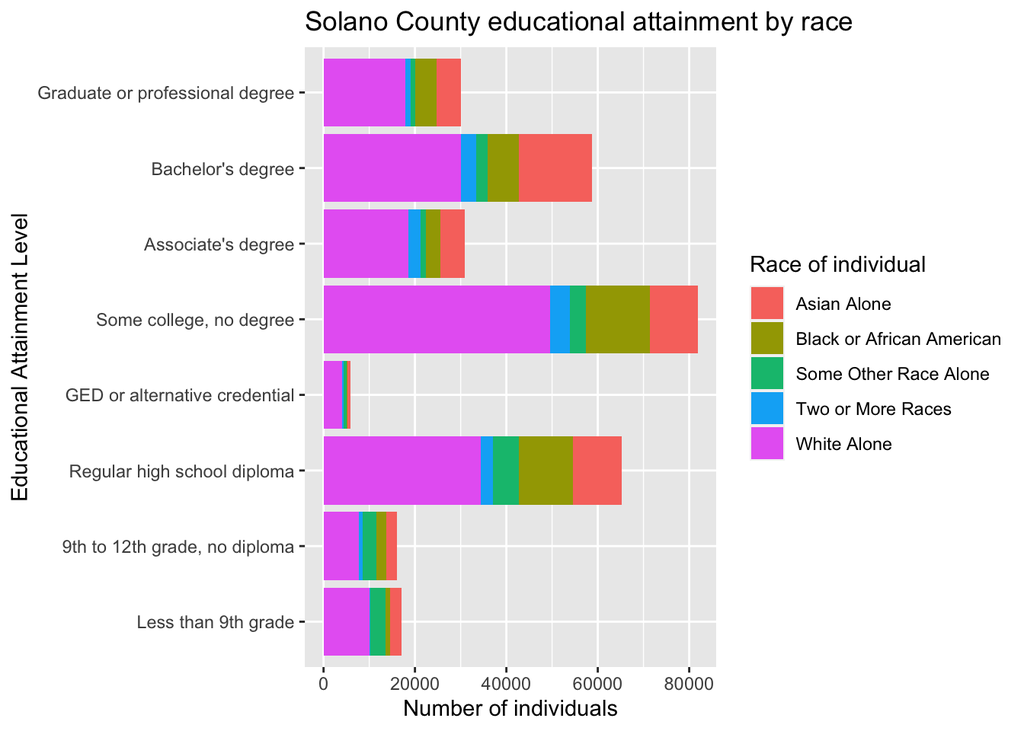

```r
## visualize
solano_education_race %>%
  group_by(education, race) %>%
  summarize(estimate = sum(estimate)) %>%
  ggplot() +
  geom_bar(
    aes(
      x = education %>% factor(levels = solano_education_race$education[1:8]),
      y = estimate,
      fill = race
    ),
    stat = "identity",
    position = "stack"
  ) +
  labs(
    x = "Educational Attainment Level",
    y = "Number of individuals",
    title = "Solano County educational attainment by race",
    fill = "Race of individual"
  ) +
  coord_flip()
```

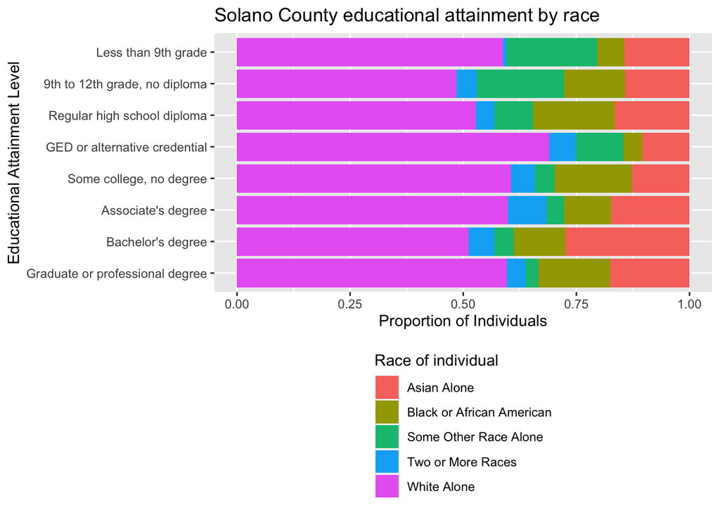

```r
## clean
solano_education_race %>%
  group_by(education, race) %>%
  summarize(estimate = sum(estimate)) %>%
  ggplot() +
  geom_bar(
    aes(
      x = education %>% factor(levels = rev(solano_education_race$education[1:8])),
      y = estimate,
      fill = race
    ),
    stat = "identity",
    position = "fill"
  ) +
  labs(
    x = "Educational Attainment Level",
    y = "Proportion of Individuals",
    title = "Solano County educational attainment by race",
    fill = "Race of individual"
  ) +
  coord_flip() +
  theme(
    legend.position = "bottom",
    legend.direction = "vertical"
  )
```

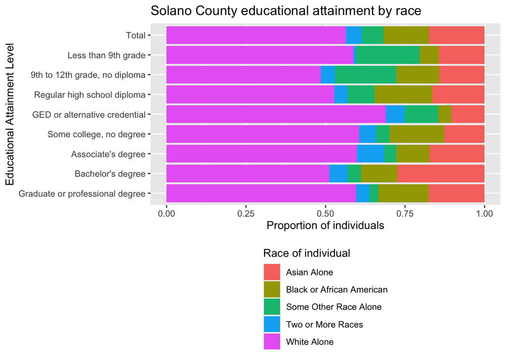

```r
#with total pop line
solano_race_total <-
  solano_education_race %>%
  group_by(race) %>%
  summarize(estimate = sum(estimate)) %>%
  mutate(education = "Total")

solano_education_race %>%
  group_by(education, race) %>%
  summarize(estimate = sum(estimate)) %>%
  rbind.data.frame(solano_race_total) %>%
  ggplot() +
  geom_bar(
    aes(
      x = education %>% factor(levels = rev(c("Total",solano_education_race$education[1:8]))),
      y = estimate,
      fill = race
    ),
    stat = "identity",
    position = "fill"
  ) +
  labs(
    x = "Educational Attainment Level",
    y = "Proportion of individuals",
    title = "Solano County educational attainment by race",
    fill = "Race of individual"
  ) +
  coord_flip() +
  theme(
    legend.position = "bottom",
    legend.direction = "vertical"
  )
```

```r
#summarize - work from here
solano_race_total_filtered <-
  solano_race_total %>%
      filter(!is.na(estimate))

((sum(solano_race_total_filtered$estimate[1:4])/sum(solano_race_total_filtered$estimate))*100) %>% round()
```

```
## [1] 44
```

```r
# no college degree
((solano_education_race %>%
  filter(education %in% solano_education_race$education[1:5]) %>%
  filter(race != "White Alone") %>%
  filter(!is.na(estimate)) %>%
  pull(estimate) %>%
  sum()) /
  (solano_education_race %>%
    filter(education %in% solano_education_race$education[1:5]) %>%
    filter(!is.na(estimate)) %>%
    pull(estimate) %>%
    sum()) * 100) %>%
  round()
```

```
## [1] 43
```

```r
# no high school degree
((solano_education_race %>%
  filter(education %in% solano_education_race$education[1:2]) %>%
  filter(race != "White Alone") %>%
  filter(!is.na(estimate)) %>%
  pull(estimate) %>%
  sum()) /
  (solano_education_race %>%
    filter(education %in% solano_education_race$education[1:2]) %>%
    filter(!is.na(estimate)) %>%
    pull(estimate) %>%
    sum()) * 100) %>%
  round()
```

```
## [1] 46
```

```r
# % more likely than expect
((((solano_education_race %>%
  filter(education %in% solano_education_race$education[1:2]) %>%
  filter(race != "White Alone") %>%
   filter(!is.na(estimate)) %>%
    pull(estimate) %>%
  sum()) /
  (solano_education_race %>%
    filter(education %in% solano_education_race$education[1:2]) %>%
     filter(!is.na(estimate)) %>%
     pull(estimate) %>%
    sum())) / (sum(solano_race_total_filtered$estimate[1:4])/sum(solano_race_total_filtered$estimate)) - 1) * 100) %>%
  round()
```

```
## [1] 6
```

**K-12 students who have no internet access at home** As shown below, the percent of students without internet access across the Bay Area can be as high as 43%, though it is typically much lower. This is based on 2018 5-yr ACS data. This finding surfaces a major challenge for K-12 students during the pandemic. Remote learning is likely to dramatically affect PUMAs where many students lack internet access.

```r
install.packages('plyr', repos = "http://cran.us.r-project.org")
install.packages("devtools")
devtools::install_github("walkerke/tidycensus")
```

```r
library(tidycensus)

census_api_key("4f72aacca75dfee9cd757936cb195dc258bd73ca")
# 2018

ca_pums_2 <- get_pums(
  variables = c(
    "PUMA",
    "ACCESS",
    "SCHG",
    "WGTP",
    "NOC"
  ),
  state = "CA",
  year = 2018,
  survey = "acs5",
  recode = T
)
```

[output not shown]

[output cut: 18336 more lines]

[output not shown]

```r
#ca pumas
bay_county_names <-
  c(
    "Alameda",
    "Contra Costa",
    "Marin",
    "Napa",
    "San Francisco",
    "San Mateo",
    "Santa Clara",
    "Solano",
    "Sonoma"
  )

bay_counties <-
  counties("CA", cb = T, progress_bar = F) %>%
  filter(NAME %in% bay_county_names)

ca_pumas <-
  pumas("CA", cb = T, progress_bar = F)

bay_pumas <-
  ca_pumas %>%
  st_centroid() %>%
  .[bay_counties, ] %>%
  st_set_geometry(NULL) %>%
  left_join(ca_pumas %>% select(GEOID10)) %>%
  st_as_sf()

bay_pums_2 <-
  ca_pums_2 %>%
  filter(PUMA %in% bay_pumas$PUMACE10)
```

```r
# all k12

bay_pums_2$SCHG <- as.numeric(bay_pums_2$SCHG)
bay_pums_2$NOC <- as.numeric(bay_pums_2$NOC)

bay_pums_test <-
  bay_pums_2 %>%
  mutate(
  all_k12 = ifelse(
    (SCHG >= 2 & SCHG <= 14),
    PWGTP,
    0
  )
  )

#final internet access
bay_pums_test$ACCESS <- as.numeric(bay_pums_test$ACCESS)

bay_pums_example_2 <-
  bay_pums_test %>%
  filter(!duplicated(SERIALNO)) %>%
  mutate(
    k12_noaccess = ifelse(
      (ACCESS == "3") &
      (SCHG >= 2 & SCHG <= 14),
      PWGTP,
      0
    )
  ) %>%
  group_by(PUMA) %>%
  summarize(
    perc_k12_noaccess =
      sum(k12_noaccess, na.rm =T)/sum(all_k12, na.rm = T)*100
  ) %>%
  left_join(
    bay_pumas %>%
      select(PUMACE10),
    by = c("PUMA" = "PUMACE10")
  ) %>%
  na.omit() %>%
  st_as_sf()
```

```r
#visualize
pums_pal <- colorNumeric(
  palette = "Oranges",
  domain = bay_pums_example_2$perc_k12_noaccess
)

leaflet() %>%
  addTiles() %>%
  addPolygons(
    data = bay_pums_example_2,
    fillColor = ~pums_pal(perc_k12_noaccess),
    color = "white",
    opacity = 0.5,
    fillOpacity = 0.5,
    weight = 1,
    label = ~paste0(
      round(perc_k12_noaccess),
      "% K-12 students with no access to the internet"
    ),
    highlightOptions = highlightOptions(
      weight = 2,
      opacity = 1
    )
  ) %>%
  addLegend(
    data = bay_pums_example_2,
    pal = pums_pal,
    values = ~perc_k12_noaccess,
    title = "% K-12<br> students with no <br>access to internet"
  )
```

[interactive chart not shown]

**Migration by Education in Solano County** The following analysis uses the Geographical Mobility data by Educational Attainment from the 1-yr 2018 and 2019 ACS data. It is important to note that this data is for the population 25 and older, meaning those who are currently pursuing high school and college degrees are not captured in the analysis.

```r
#2.3 migration Solano County

library(tidyverse)
library(censusapi)

Sys.setenv(CENSUS_KEY="4f72aacca75dfee9cd757936cb195dc258bd73ca")

acs_vars_2019_1yr <-
  listCensusMetadata(
    name = "2019/acs/acs1",
    type = "variables"
  )

acs_vars_2018_1yr <-
  listCensusMetadata(
    name = "2018/acs/acs1",
    type = "variables"
  )
```

```r
smc_mobility_current_19_edu <-
  getCensus(
    name = "acs/acs1",
    vintage = 2019,
    region = "county:095",
    regionin = "state:06",
    vars = c("group(B07009)")
  ) %>%
  select(!c(GEO_ID,state,NAME) & !ends_with(c("EA","MA","M"))) %>%
  pivot_longer(
    ends_with("E"),
    names_to = "variable",
    values_to = "estimate"
  ) %>%
  left_join(
    acs_vars_2019_1yr %>%
      select(name, label),
    by = c("variable" = "name")
  ) %>%
  select(-variable)


smc_mobility_current_19_edu <-
  getCensus(
    name = "acs/acs1",
    vintage = 2019,
    region = "county:095",
    regionin = "state:06",
    vars = c("group(B07009)")
  ) %>%
  select(!c(GEO_ID,state,NAME) & !ends_with(c("EA","MA","M"))) %>%
  pivot_longer(
    ends_with("E"),
    names_to = "variable",
    values_to = "estimate"
  ) %>%
  left_join(
    acs_vars_2019_1yr %>%
      select(name, label),
    by = c("variable" = "name")
  ) %>%
  select(-variable) %>%
  separate(
    label,
    into = c(NA,NA,"mobility","education"),
    sep = "!!"
  ) %>%
  mutate(
    mobility = ifelse(
      mobility %in% c("Same house 1 year ago:", "Moved within same county:"),
      "Here since last year",
      "Inflow"
    )
  ) %>%
  filter(!is.na(education)) %>%
  group_by(mobility, education) %>%
  summarize(estimate = sum(estimate))
```

```r
#last year - only one dataset for education and mobility so use last year = 2018 data
smc_mobility_lastyear_18_edu <-
  getCensus(
    name = "acs/acs1",
    vintage = 2018,
    region = "county:095",
    regionin = "state:06",
    vars = c("group(B07009)")
  ) %>%
  select(!c(GEO_ID,state,NAME) & !ends_with(c("EA","MA","M"))) %>%
  pivot_longer(
    ends_with("E"),
    names_to = "variable",
    values_to = "estimate"
  ) %>%
  left_join(
    acs_vars_2018_1yr %>%
      select(name, label),
    by = c("variable" = "name")
  ) %>%
  select(-variable)

smc_mobility_lastyear_18_edu <-
  getCensus(
    name = "acs/acs1",
    vintage = 2018,
    region = "county:095",
    regionin = "state:06",
    vars = c("group(B07009)")
  ) %>%
  select(!c(GEO_ID,state,NAME) & !ends_with(c("EA","MA","M"))) %>%
  pivot_longer(
    ends_with("E"),
    names_to = "variable",
    values_to = "estimate"
  ) %>%
  left_join(
    acs_vars_2018_1yr %>%
      select(name, label),
    by = c("variable" = "name")
  ) %>%
  select(-variable) %>%
  separate(
    label,
    into = c(NA,NA,"mobility","education"),
    sep = "!!"
  ) %>%
  mutate(
    mobility = ifelse(
      mobility %in% c("Same house 1 year ago:", "Moved within same county:"),
      "Here since last year",
        ifelse(mobility %in% c("Less than high school graduate", "High school graduate (includes equivalency)", "Some college or associate's degree", "Bachelor's degree","Graduate or professional degree"),"NA",
      "Outflow"
    )
  )) %>%
  filter(!is.na(education)) %>%
    filter(!is.na(mobility))%>%
  group_by(mobility, education) %>%
  summarize(estimate = sum(estimate))
```

```r
#to get total population
smc_mobility_current_18_edu <-
  getCensus(
    name = "acs/acs1",
    vintage = 2018,
    region = "county:095",
    regionin = "state:06",
    vars = c("group(B07009)")
  ) %>%
  select(!c(GEO_ID,state,NAME) & !ends_with(c("EA","MA","M"))) %>%
  pivot_longer(
    ends_with("E"),
    names_to = "variable",
    values_to = "estimate"
  ) %>%
  left_join(
    acs_vars_2019_1yr %>%
      select(name, label),
    by = c("variable" = "name")
  ) %>%
  select(-variable) %>%
  separate(
    label,
    into = c(NA,NA,"mobility","education"),
    sep = "!!"
  ) %>%
  mutate(
    mobility = "Here last year"
  ) %>%
  filter(!is.na(education)) %>%
  group_by(mobility, education) %>%
  summarize(estimate = sum(estimate))
```

```r
##bind

smc_flows_19_edu <-
  rbind.data.frame(
    smc_mobility_current_18_edu,
    smc_mobility_lastyear_18_edu %>%
      filter(mobility == "Outflow"),
    smc_mobility_current_19_edu %>%
      filter(mobility == "Inflow"),
    smc_mobility_current_19_edu %>%
      group_by(education) %>%
      summarize(estimate = sum(estimate)) %>%
      mutate(mobility = "Here this year")
  ) %>%
  pivot_wider(
    names_from = mobility,
    values_from = estimate
  ) %>%
  mutate(
    `External net` = Inflow - Outflow,
    `Internal net` = `Here this year` - `Here last year` - `External net`,
  ) %>%
  select(
    `Education tier` = education,
    `Internal net`,
    `External net`,
    `Here last year`,
    `Here this year`,
    Outflow,
    Inflow
  )

smc_flows_19_edu
```

```
## # A tibble: 5 x 7
##   `Education tier` `Internal net` `External net` `Here last year`
##   <chr>                     <dbl>          <dbl>            <dbl>
## 1 Bachelor's degr…          57066         -55623            57916
## 2 Graduate or pro…          28474         -25591            27580
## 3 High school gra…          68210         -67102            72214
## 4 Less than high …          30780         -30936            33645
## 5 Some college or…         107023        -110484           117535
## # … with 3 more variables: `Here this year` <dbl>, Outflow <dbl>, Inflow <dbl>
```

The internal net means there are that many more people with that degree. As people reach the age of 25 and are counted in the census, these would be considered people coming in at those degree levels, as well as those who are gaining higher degrees if they were already included (e.g. a Bachelor’s degree individual now gaining a graduate degree). In Solano County, this is showing that there are nearly twice the amount of people coming in with “Some college or associate’s degree” than with “Bachelor’s degree”.

The data shows quite a bit of migration, but the numbers of people that were here this year are similar to those that were here last year. This demonstrates that there is quite a bit of educational mobility at least in and out of Solano County.